# Lesson 2 - Data Visualisation 2 Answers

# Load libraries and Data

Load the libraries and data necessary to complete the exercises associated with this lesson.

You may have to install the `languageR` library if you don’t have it installed already.

```r
library(tidyverse)
library(ggpirate)
# install.packages("languageR") # install if needed
library(languageR)
```

Next, we’ll tidy up the data sets so they include only the variables you need for these exercises. We’ll cover this process in later sessions, but it’s useful to see the code now for when it comes to revising this course.

First, we’ll use the `lexdec` data set from `languageR`. This contains lexical decision times (is this a word or not?) for a range of subjects with different native languages over different words. We also get information on the class of the words (animal or plant), and on the frequency of the words (i.e. how often they occur in most texts). Finally, our dependent variable is reaction time in the lexical decision task.

Then we’ll create our own demographic data, using part of the `lex_dec` data for use in other plots.

```r
 # lexical decision times split by subject and item
lex_dec <- lexdec %>%
  select(Subject, NativeLanguage, Trial, Word, Class, Frequency, RT) %>%
  rename_all(tolower) %>%
  rename(native_language = nativelanguage, reaction_time = rt) %>%
  as.tibble()

# aggregate by items to explore differences in items
lex_dec_items <- lex_dec %>%
  group_by(word, class, frequency) %>%
  summarise(mean_RT = mean(reaction_time),
            sd_RT = sd(reaction_time)
  )
# ensure same values for gender and age columns
set.seed(1892)

# create demographic information
# here, I've simulated gender and age data
lex_demog <- lex_dec %>%
  distinct(subject, native_language) %>%
  mutate(age = rnorm(n = nrow(.), mean = 35, sd = 7),
         gender = sample(c("male", "female"),
                      size = nrow(.),
                      replace = TRUE)
         )
```

# Exercises

Enter your code in the code blocks in response to the [exercises for Chapter 3 of r4psych](http://glennwilliams.me/r4psych/data-visualisation-2.html#exercises-1). Run your code and then save your document once completed.

## Question 1

Using the `lex_dec_items` data set, make a density plot of the word frequency by class. Save this plot as `lexical_density`, and output the plot.

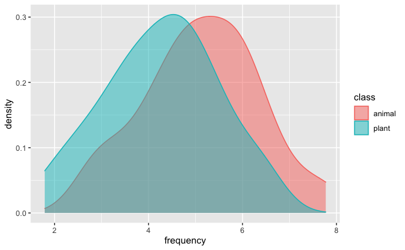

```r
lexical_density <-
  ggplot(data = lex_dec_items,
         mapping = aes(x = frequency,
                       colour = class,
                       fill = class
                       )
         ) +
  geom_density(alpha = 0.5)

lexical_density
```

## Question 2

Add a black and white theme to your `lexical_density` plot. Next, give the axis labels and legend labels uppercase names. Finally, give your legend title the name Word Class. Assign all of this to a new object `lexical_density_improved`, and output your plot below.

*Note*: To change the legend labels, you need to use both `scale_fill_discrete` and `scale_colour_discrete`. Why do you think this is? Why don’t we just use `scale_x_discrete` as we did in class?

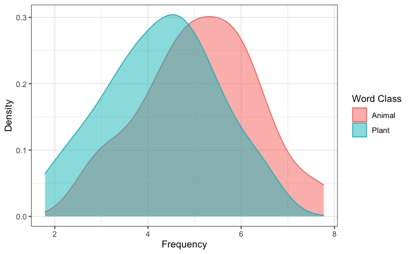

```r
# plot
lexical_density_improved <-
  lexical_density +
  labs(x = "Frequency", y = "Density") +
  guides(fill = guide_legend(title = "Word Class"),
         colour = guide_legend(title = "Word Class")
         ) +
  scale_fill_discrete(labels = c("Animal", "Plant")) +
  scale_colour_discrete(labels = c("Animal", "Plant")) +
  theme_bw()

# return plot
lexical_density_improved
```

## Question 3

There’s some repetition in the code for the plot above. Can you improve your code to remove that?

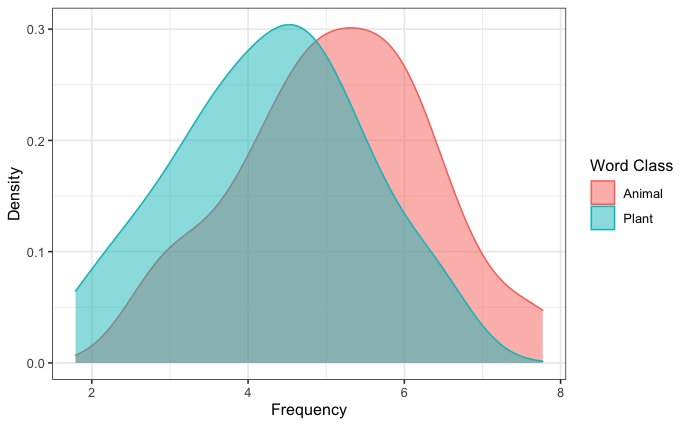

```r
# define labels
legend_title_name <- guide_legend(title = "Word Class")
legend_label_names <- c("Animal", "Plant")

# plot
lexical_density_improved <-
  lexical_density +
  labs(x = "Frequency", y = "Density") +
  guides(fill = legend_title_name,
         colour = legend_title_name
         ) +
  scale_fill_discrete(labels = legend_label_names) +
  scale_colour_discrete(labels = legend_label_names) +
  theme_bw()

# return plot
lexical_density_improved
```

## Question 4

Now we want to check the distribution of the reaction times depending on word class and the language spoken by our participants.

Using the `lex_dec` data set, create a faceted plot that looks at the density of reaction times. This should be made up of a grid of densities split by native language and word class.

Assign this to the object `rt_density` and output your plot.

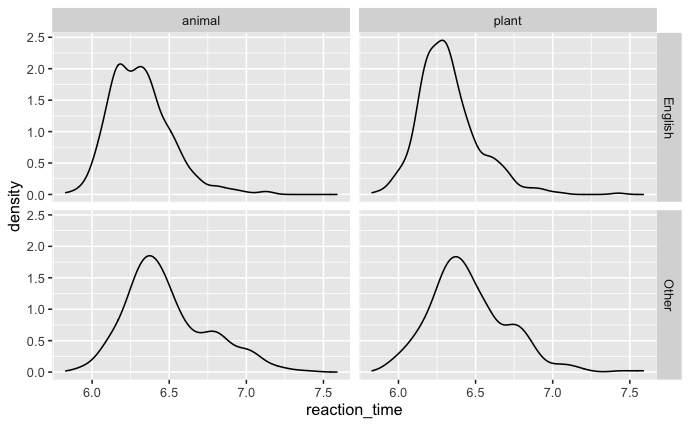

```r
# plot
rt_density <-
  ggplot(data = lex_dec,
       mapping = aes(x = reaction_time)
       ) +
  geom_density() +
  facet_grid(native_language ~ class)

# return plot
rt_density
```

## Question 5

Now we want to explore if there’s any relationship between the mean reaction time to our items and the frequency of the item.

Using the `lex_dec_items` data set, plot the relationship between word frequency and mean reaction time as a scatter plot. We want a fitted line and points for the mean reaction time.

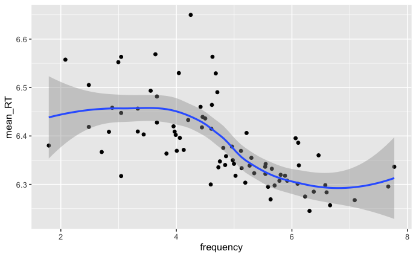

```r
ggplot(data = lex_dec_items,
       mapping = aes(x = frequency,
                     y = mean_RT
                     )
       ) +
  geom_point() +
  geom_smooth()
```

## Question 6

Now we want to know how many males and females took part in our experiment.

Using the `lex_demog` data set, create a count of the number of males and females who took part in the experiment. Make all text in the plot uppercase, and make the plot theme black and white.

Assign this to the object `gender_count` and output your plot.

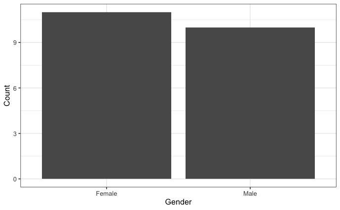

```r
# plot
gender_count <-
  ggplot(data = lex_demog,
       mapping = aes(x = gender)) +
  geom_bar() +
  labs(x = "Gender", y = "Count") +
  scale_x_discrete(labels = c("Female", "Male")) +
  theme_bw()

# return plot
gender_count
```

## Question 7

What if we want to know the mean age and distribution of ages split by language spoken and gender?

Using the `lex_demog` data set, create a pirate plot of the ages by each gender. You can set the colour and fill to gender to have more colourful plot if you’d prefer.

Additionally, we would like these plots split by the native language of the speaker, so facet your plot by native language.

Assign this all to the object `demographic_age`, and output your plot.

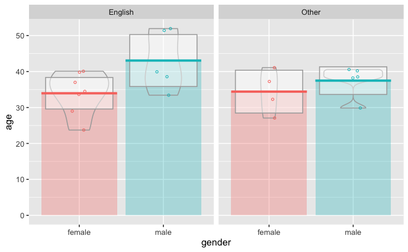

```r
# plot
demographic_age <-
  ggplot(data = lex_demog,
         mapping = aes(x = gender,
                       y = age,
                       colour = gender,
                       fill = gender
                       )
         ) +
  geom_pirate() +
  facet_wrap(~ native_language)

# return plot
demographic_age
```

Can you see how a bar plot of the average ages might be misleading in this instance? Pay particular attention to the male bar for the other language group.

## Question 8

Next, we want to see the mean (and standard error) of reaction times to words with different word frequencies.

Using the `lex_dec` data set, create a scatter plot of the reaction time by word frequency. We would like this split by word class.

*Hint*: Be sure to use the `stat_summary` function to get pointranges that represent the mean and standard error.

Assign this to the object `rt_pointrange`, and output your plot.

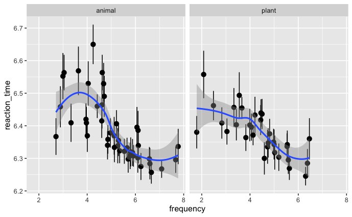

```r
# plot
rt_pointrange <-
  ggplot(data = lex_dec,
       mapping = aes(
         x = frequency,
         y = reaction_time
         )
       ) +
  stat_summary(fun.data = "mean_se", geom = "pointrange") +
  geom_smooth() +
  facet_wrap(~ class)

# return plot
rt_pointrange
```

## Question 9

Finally, we want to show a few of our graphs in one display.

Add the labels A-D to identify each plot.

Save these plots under the object `combined_plots` and return your combined plots.

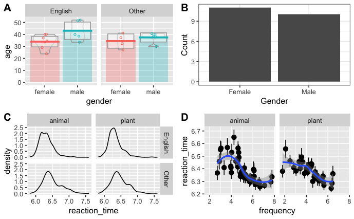

```r
# load library
library(cowplot)

# plot
combined_plots <- plot_grid(
  demographic_age,
  gender_count,
  rt_density,
  rt_pointrange,
  labels = c("A", "B", "C", "D")
)
# return plot
combined_plots
```

# Additional Exercise

We can improve the combined plots above.

Add a (short) simple title to your combined plots, and save this plot in the outputs folder.

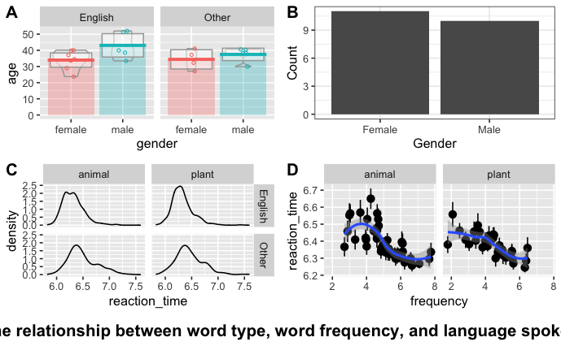

```r
# define title
title <- ggdraw() +
  draw_label("The relationship between word type, word frequency, and language spoken",
             fontface = "bold")

# combine plots
combined_plots <- plot_grid(
  combined_plots,
  title,
  ncol = 1,
  rel_heights = c(1, 0.1)
)

# return plot
combined_plots

# save plot
ggsave(filename = "outputs/combined_plots.png",
       plot = combined_plots
       )
```

These plots won’t look perfect, and you may need to change the font and element sizes. That can be easily achieved, but we won’t do that here.